# How does popularity, number of authors, and number of tests relate?

```r
devtools::install_local(".", force = TRUE, upgrade = "never")
```

```r
library(pkgsearchsandbox)
library(pkgsearch)
library(ggplot2)
devtools::install_github("rsquaredacademy/pkginfo")
library(pkginfo)
```

# What do we think is going on with popularity, number of authors, and number of tests?

In our discussions, we though that more popular packages likely have more authors and also more tests. It would be interesting to see if this holds in the R universe.

# Number of Authors and popularity

The package {pkgsearch} allows you to obtain metadata about packages on CRAN. We can use this to look at how number of authors and popularity relates.

```r
df <- pkgsearch::advanced_search("ecology", size = 200)
df
```

| score | package | version | title | description | date | maintainer_name | maintainer_email | revdeps | downloads_last_month | license | url | bugreports | package_data |
| --- | --- | --- | --- | --- | --- | --- | --- | --- | --- | --- | --- | --- | --- |
| 8.977746 | gen3sis |  | General Engine for Eco-Evolutionary Simulations | Contains an engine for spatially-explicit eco-evolutionary mechanistic models with a modular implementation and several support functions. It allows exploring the consequences of ecological and macroe… | 2021-10-27 11:00:08 | Oskar Hagen | oskar@hagen.bio | 1 | 829 | GPL-3 | https://github.com/project-Gen3sis/R-package | https://github.com/project-Gen3sis/R-package/issues | > |
| 8.918427 | signibox |  | Statistical Significance Marks on Boxplots | Add significance marks to any R Boxplot, including a given significance niveau. | 2022-03-21 07:30:08 | Louis-Marvin Sander | louis.sander@web.de | 1 | 304 | GPL (>= 2) | NA | NA | > |
| 8.136474 | RevEcoR |  | Reverse Ecology Analysis on Microbiome | An implementation of the reverse ecology framework. Reverse ecology\nrefers to the use of genomics to study ecology with no a priori assumptions\nabout the organism(s) under consideration, linking org… | 2016-04-03 17:14:01 | Yang Cao | yiluheihei@gmail.com | 1 | 289 | GPL (>= 2) | NA | NA | > |
| 7.757165 | eiPack |  | Ecological Inference and Higher-Dimension Data Management | Provides methods for analyzing R by C ecological contingency\ntables using the extreme case analysis, ecological regression,\nand Multinomial-Dirichlet ecological inference models. Also\nprovides tool… | 2020-02-13 06:10:02 | Michael Kellermann | mrkellermann@gmail.com | 2 | 731 | GPL (>= 2) \| file LICENSE | http://www.olivialau.org/software | NA | > |
| 7.670579 | soundecology |  | Soundscape Ecology | Functions to calculate indices for soundscape ecology and other ecology research that uses audio recordings. | 2018-03-05 03:10:15 | Luis J. Villanueva-Rivera | ljvillanueva@coquipr.com | 1 | 503 | GPL-3 | http://ljvillanueva.github.io/soundecology/ | http://github.com/ljvillanueva/soundecology/issues | > |
| 7.670579 | ei |  | Ecological Inference | Software accompanying Gary King's book: A Solution to the Ecological Inference Problem. (1997). Princeton University Press. ISBN 978-0691012407. | 2016-11-05 00:49:10 | James Honaker | zelig.zee@gmail.com | 1 | 477 | GPL (>= 2) | http://gking.harvard.edu/eiR,\nhttp://gking.harvard.edu/eicamera/kinroot.html | NA | > |
| 7.467925 | ecospace |  | Simulating Community Assembly and Ecological Diversification\nUsing Ecospace Frameworks | Implements stochastic simulations of community assembly (ecological\ndiversification) using customizable ecospace frameworks (functional trait\nspaces). Provides a wrapper to calculate common ecologic… | 2020-06-13 16:50:03 | Phil Novack-Gottshall | pnovack-gottshall@ben.edu | 1 | 298 | CC0 | https://github.com/pnovack-gottshall/ecospace,\nhttp://www.ben.edu/faculty/pnovack-gottshall/index.html | https://github.com/pnovack-gottshall/ecospace/issues | > |
| 7.409203 | spThin |  | Functions for Spatial Thinning of Species Occurrence Records for\nUse in Ecological Models | A set of functions that can be used to spatially thin\nspecies occurrence data. The resulting thinned data can be used in ecological\nmodeling, such as ecological niche modeling. | 2019-11-15 17:10:03 | Matthew E. Aiello-Lammens | matt.lammens@gmail.com | 3 | 2607 | GPL-3 | NA | https://github.com/mlammens/spThin/issues | > |
| 7.181486 | EML |  | Read and Write Ecological Metadata Language Files | Work with Ecological Metadata Language ('EML') files.\n'EML' is a widely used metadata standard in the ecological and\nenvironmental sciences, described in Jones et al. (2006),\n. | 2022-04-28 16:40:02 | Carl Boettiger | cboettig@gmail.com | 7 | 5869 | MIT + file LICENSE | https://docs.ropensci.org/EML/, https://github.com/ropensci/EML/ | https://github.com/ropensci/EML/issues | > |
| 7.172960 | EcoIndR |  | Ecological Indicators | Calculates several indices, such as of diversity, fluctuation, etc., and they are used to estimate ecological indicators. | 2022-02-22 15:50:03 | Cástor Guisande González | castor@uvigo.es | 1 | 937 | GPL (>= 2) | NA | NA | > |

[output cut: 190 more lines]

Number of Authors can be counted from Author tags within the metadata.

```r
df <- pkgsearchsandbox::count_authors(df)
```

For popularity, there are many ways that this could be indexed. The simplest way given the {pkgsearch} results is looking at last months downloads.

Now, we will plot number of downloads last month vs number of authors, with a smoother.

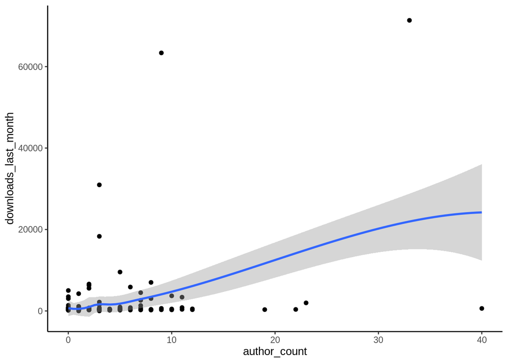

```r
ggplot(df, aes(x = author_count, y = downloads_last_month))+
  geom_point()+
  geom_smooth()+
  theme_classic()
```

# TODO: learn more about tests

It would be great to learn things about how many tests are done for the packages. Maybe there is some information in the metadata. If not, could maybe look for this info by looking on github; either in the CRAN mirror, or maybe more appropriately the github repo. This would allows us to look at if testthat is being used; How many tests there are; If codecov is being used and what the code cov is; If any github actions are being used. Perhaps this would give us some idea for ecology packages.

## Hypotheses

Expect more tests, more automation, and higher coverage for packages that have more downloads.

## Code coverage

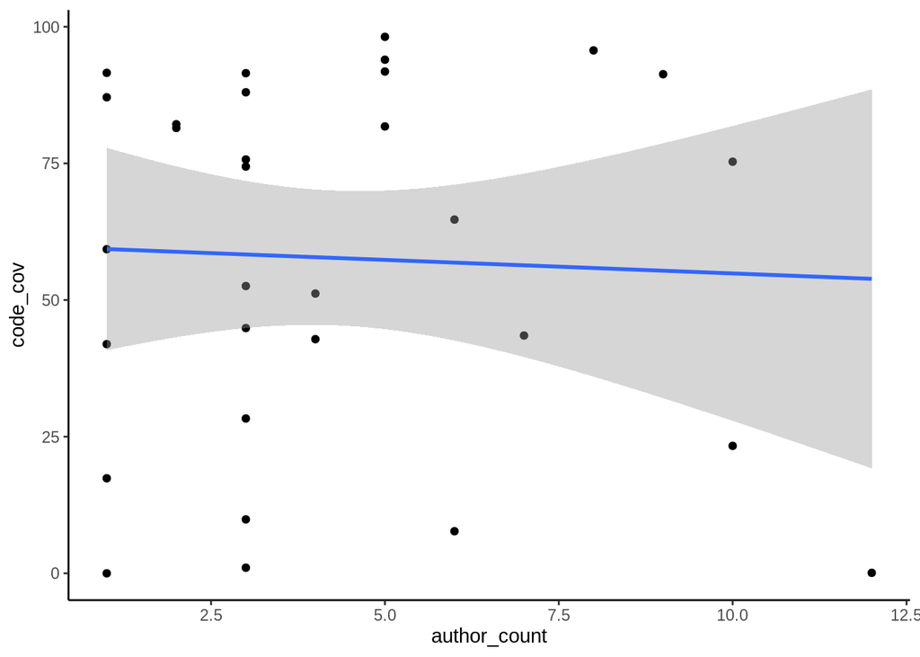

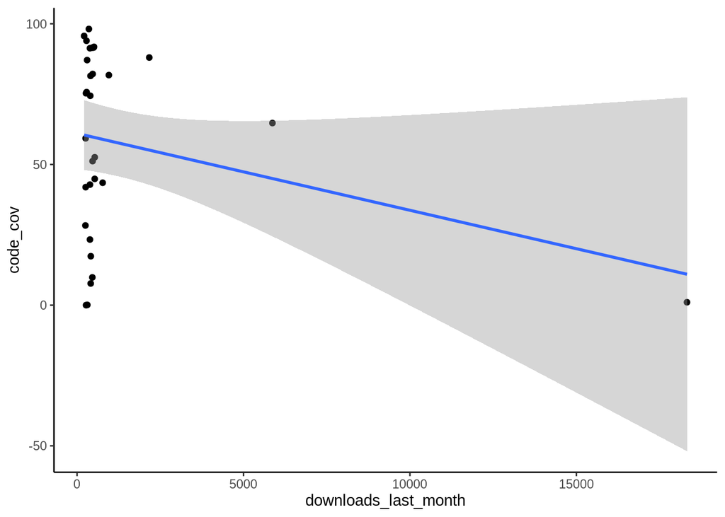

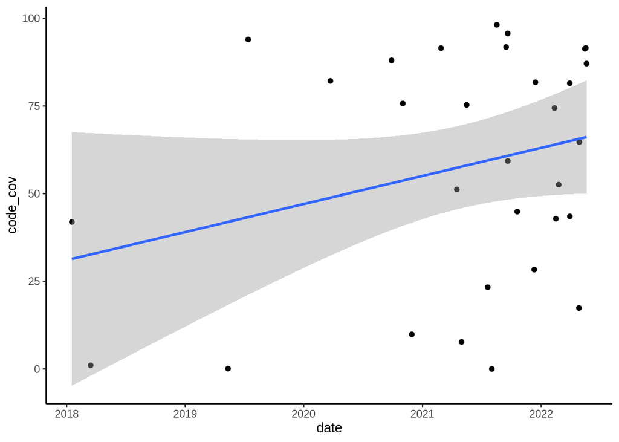

Histogram of code coverage:

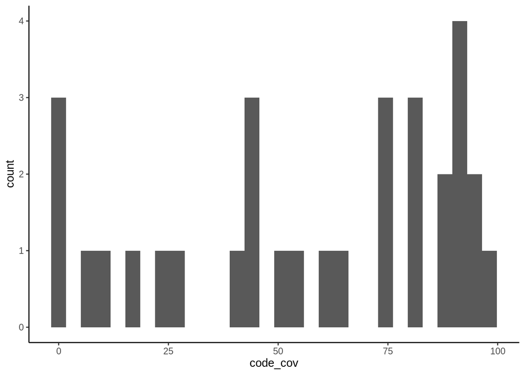

It looks like code coverage is all over the place, at least for this subset of packages.

# TODO: Is there a better search term besides ecology?

Other topics: statistics (maybe too broad), marine, population dynamics (too narrow?)?

We could also consider trying to take a random subset of R packages from CRAN (not sure how to do this with pkgsearch, though) and looking at stats to just get a general idea of what the trend is with R packages more generally. There may be a way to do this through the [metacran](https://www.r-pkg.org/). Basically, just need a list of all cran pkg names, take a random subset of a certain size or percentage, query to find count of authors and number of downloads.

The function `tools::CRAN_package_db()` may be helpful for selecting a random sample without needing to specify a search tearm. The authors are listed, but may need to come up with a creative way to look at things like popularity. In addition, may need to filter by github URL first (maybe either using the BugReports link in or URL).